# Assignment 3.1

Name: Francisco Gutierrez

Date: September 21, 2022

For this assignment, you will refer to the textbook to solve the practice exercises. **Use Python to answer any coding problems (not R, even if indicated in your textbook).** Use Jupyter Notebook, Google Colab, or a similar software program to complete your assignment. Submit your answers as a **PDF or HTML** file. As a best practice, always label your axes and provide titles for any graphs generated on this assignment. Round all quantitative answers to 2 decimal places.

## Problem 3.2.

In an exit poll of 1648 voters in the 2020 Senatorial election in Arizona, 51.5% said they voted for Mark Kelly and 48.5% said they voted for Martha McSally

a) Suppose that actually 50% of the population voted for Kelly. If this exit poll had the properties of a simple random sample, find the standard error of the sample proportion voting for him.

b) Under the 50% presumption, are the results of the exit poll surprising? Why? Would you be willing to predict the election outcome? Explain by (i) conducting a simulation; (ii) using the value found in (a) for the standard error.

(a) The standard error, given by $$ SE(\hat{p}) = \sqrt{\frac{p(1-p)}{n}} $$ is about 0.0123166 or 1.23 percentage points.

(b) The results are not surprising under the assumption that 50% of the population voted for Kelly. In a simulation of 100,000 polls of 1,648 voters each, using a probability of 0.50 and random seed 42, 11.29% of the polls showed support of at least 51.50% for Kelly. Using the standard error from part (a),

$$ z = \frac{\hat{p}-p}{SE(\hat{p})} = \frac{0.515-0.50}{0.0123166} \approx 1.22 $$

The observed support is only 1.22 standard errors above 50%, so this lead could reasonably occur through random sampling. I would not confidently predict the winner from this poll alone.

## Problem 3.3.

The 49 students in a class at the University of Florida made blinded evaluations of pairs of cola drinks. For the 49 comparisons of Coke and Pepsi, Coke was preferred 29 times. In the population that this sample represents, is this strong evidence that a majority prefers Coke? Use a simulation of a sampling distribution to answer.

[figure not shown]

The sample proportion that preferred Coke was 29 out of 49, or 59.18%. To see whether this is strong evidence of a population majority, I used a simulation assuming that Coke and Pepsi are equally preferred, so the population proportion is 0.50. In 100,000 simulated samples of 49 people, using random seed 42, 12.65% had 29 or more people prefer Coke. This result is not very unusual under equal preference, so the difference could reasonably be due to sampling variability. I would not consider this strong evidence that a majority of the population prefers Coke, even though a majority of this sample did.

## Problem 3.5.

The example in Section 3.1.4 simulated sampling distributions of the sample mean to determine how precise $\bar{Y}$ for $n=25$ may estimate a population mean $\mu.$

a) Find the theoretical standard error of $\bar{Y}$ for the scenario values of $\sigma = 5$ and 8. How do they compare to the standard deviations of the 100,000 sample means in the simulations?

(a) The standard error tells us how much the sample mean varies from one random sample to another. The values from the book are:

| Scenario | Population mean $\mu$ | Population standard deviation $\sigma$ | Sample size $n$ |
| --- | --- | --- | --- |
| First | 20.00 dollars | 5.00 dollars | 25 |
| Second | 24.00 dollars | 8.00 dollars | 25 |

Here, $\bar{Y}$ is the sample mean, $\mu$ is the population mean, $\sigma$ is the population standard deviation, and $n$ is the number of people in each sample. The theoretical standard error is:

$$ SE(\bar{Y})=\frac{\sigma}{\sqrt{n}} $$

For the first scenario:

$$ SE(\bar{Y})=\frac{5}{\sqrt{25}}=\frac{5}{5}=1.00\text{ dollar} $$

For the second scenario:

$$ SE(\bar{Y})=\frac{8}{\sqrt{25}}=\frac{8}{5}=1.60\text{ dollars} $$

To compare these with simulated results, I repeated the simulation in Python using 100,000 independent samples of 25 observations for each scenario. I used NumPy's default random generator with seed 42, restarting the generator for each scenario. These are my simulation results, rather than the exact results from the book.

For a gamma distribution, the shape $k$ and scale $\theta$ are calculated from the population mean and standard deviation:

$$ k=\left(\frac{\mu}{\sigma}\right)^2, \qquad \theta=\frac{\sigma^2}{\mu} $$

First scenario:

$$ k=\left(\frac{20}{5}\right)^2=16, \qquad \theta=\frac{5^2}{20}=1.25 $$

Second scenario:

$$ k=\left(\frac{24}{8}\right)^2=9, \qquad \theta=\frac{8^2}{24}=\frac{8}{3} $$

Each scenario uses $100{,}000\times25=2{,}500{,}000$ generated observations. For each sample $b$, I calculated its mean:

$$ \bar{Y}_b=\frac{1}{25}\sum_{i=1}^{25}Y_{bi} $$

Here, $Y_{bi}$ is observation $i$ in sample $b$. With $B=100{,}000$ samples, the average of those sample means and their sample standard deviation are:

$$ \bar{\bar{Y}}=\frac{1}{B}\sum_{b=1}^{B}\bar{Y}_b, \qquad s_{\bar{Y}}=\sqrt{\frac{\sum_{b=1}^{B}(\bar{Y}_b-\bar{\bar{Y}})^2}{B-1}} $$

The standard deviation $s_{\bar{Y}}$ is the simulated estimate of the standard error.

| Scenario | Average of simulated sample means | Theoretical SE | Simulated SE |
| --- | --- | --- | --- |
| First | 20.00 dollars | 1.00 dollar | 1.00 dollar |
| Second | 24.01 dollars | 1.60 dollars | 1.60 dollars |

Before rounding, the simulated standard deviations were approximately 0.997082 and 1.596618. They are very close to the theoretical values. The second scenario has a larger standard error because the individual bills have more variability, even though both samples have the same size.

b) In the first scenario, we chose $\sigma = 5$ under the belief that if $\mu = 20$, about 2/3 of the sample values would fall between `$`15 and `$`25. For the gamma distribution with $(\mu, \sigma) = (20,5),$ show that the actual probability between 15 and 25 is 0.688.

(b) For this part, $Y$ is one customer's bill, rather than the mean of 25 bills. The population mean is $\mu=20$ and the population standard deviation is $\sigma=5$. For a gamma distribution:

$$ \mu=k\theta, \qquad \sigma^2=k\theta^2 $$

The shape and scale are therefore:

$$ k=\frac{\mu^2}{\sigma^2}=\frac{20^2}{5^2}=\frac{400}{25}=16 $$

$$ \theta=\frac{\sigma^2}{\mu}=\frac{5^2}{20}=\frac{25}{20}=1.25 $$

The probability density function for these values is:

$$ f(y)=\frac{y^{15}e^{-y/1.25}}{\Gamma(16)(1.25)^{16}},\qquad y>0 $$

Here, $\Gamma$ is the gamma function, and $\Gamma(16)=15!$. The probability of a bill between 15 and 25 dollars is the area under this density between those values:

$$ P(15<Y<25)=\int_{15}^{25}f(y)\,dy=F(25)-F(15) $$

$F(y)$ is the cumulative distribution function, which gives the probability that the bill is at most $y$. Evaluating it in Python with SciPy's gamma CDF, using shape 16 and scale 1.25, gives:

$$ F(25)\approx0.8434868654, \qquad F(15)\approx0.1555843475 $$

Subtracting:

$$ P(15<Y<25)\approx0.8434868654-0.1555843475 =0.6879025179\approx0.688 $$

As a percentage:

$$ 0.6879025179\times100\%\approx68.79\% $$

So about 68.79% of individual bills would fall between 15 and 25 dollars. This is close to the belief that about two-thirds would fall in that range. The probability is shown to three decimal places to match the question; the percentage is rounded to two decimal places.

## Problem 3.8.

Construct the sampling distribution of the sample proportion of heads, for flipping a balanced coin (a) once; (b) twice; (c) three times; (d) four times. Describe how the shape changes as the number of flips $n$ increases. What would happen if $n$ kept growing? Why?

Let $H$ be the number of heads and $\hat p=H/n$ be the sample proportion of heads. For a balanced coin, $p=0.50$, and independent flips give:

$$ H\sim\operatorname{Binomial}(n,0.50),\qquad P\left(\hat p=\frac{h}{n}\right)=\binom{n}{h}(0.50)^n $$

Here, $\binom{n}{h}$ counts the different ways to get $h$ heads in $n$ flips. The exact distributions are:

| Part | Number of flips $n$ | Possible proportions of heads | Corresponding probabilities |
| --- | --- | --- | --- |
| (a) | 1 | $0,1$ | $1/2,1/2$ |
| (b) | 2 | $0,1/2,1$ | $1/4,2/4,1/4$ |
| (c) | 3 | $0,1/3,2/3,1$ | $1/8,3/8,3/8,1/8$ |
| (d) | 4 | $0,1/4,1/2,3/4,1$ | $1/16,4/16,6/16,4/16,1/16$ |

For example, with four flips there are $2^4=16$ equally likely sequences. Six have exactly two heads, so $P(\hat p=0.50)=6/16=37.50\%$. Fractions in the table keep the probabilities exact.

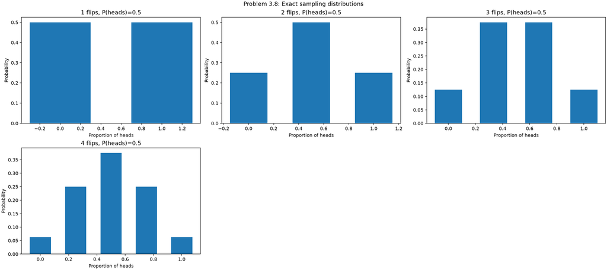

The distributions are symmetric around 0.50. With more flips, the proportions become more concentrated near 0.50 and the shape becomes more bell-shaped. The center and standard error are:

$$ E(\hat p)=0.50,\qquad SE(\hat p)=\sqrt{\frac{0.50(1-0.50)}{n}}=\frac{0.50}{\sqrt n} $$

For $n=1,2,3,4$, the standard errors are 0.50, 0.35, 0.29, and 0.25. If $n$ kept growing, the proportion would tend to get closer to 0.50 as its standard error approaches zero. This agrees with the law of large numbers; the Central Limit Theorem explains the approximately normal shape of the standardized proportions for large $n$.

## Problem 3.13.

Simulate random sampling from a uniform population distribution with several $n$ values to illustrate the Central Limit Theorem.

I used a uniform population from 0 to 1, where equal-length intervals have equal probabilities. Its mean and standard deviation are:

$$ \mu=\frac{0+1}{2}=0.50,\qquad \sigma=\frac{1-0}{\sqrt{12}}\approx0.29 $$

Using the Python chart app with seed 42, I generated 100,000 independent samples for each sample size $n=1,2,10,30$ and calculated each sample's mean. The theoretical standard error is:

$$ SE(\bar Y)=\frac{\sigma}{\sqrt n}=\frac{1}{\sqrt{12n}} $$

| Sample size | Average of simulated means | Simulated SE | Theoretical SE |
| --- | --- | --- | --- |
| 1 | 0.50 | 0.29 | 0.29 |
| 2 | 0.50 | 0.20 | 0.20 |
| 10 | 0.50 | 0.09 | 0.09 |
| 30 | 0.50 | 0.05 | 0.05 |

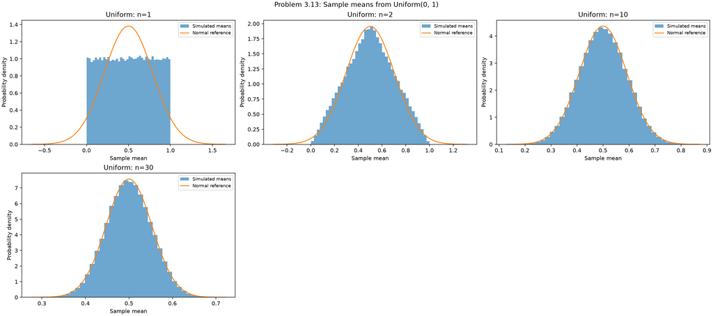

For $n=1$, the distribution is approximately flat, like the population. For $n=2$, it is roughly triangular. At $n=10$ and $n=30$, it looks more bell-shaped. The center stays close to 0.50, while the spread gets smaller. This illustrates the Central Limit Theorem: averages of independent observations from a population with finite variance become approximately normally distributed as the sample size increases. The normal reference curve is only an approximation and does not fit the small-sample cases as well.

## Problem 3.14.

On each bet in a sequence of bets, you win 1 dollar with probability 0.50 and lose 1 dollar (i.e., win negative 1 dollar) with probability 0.50. Let $Y$ denote the total of your winnings and losings after 100 bets. Giving your reasoning, state the approximate distribution of $Y.$

Let $X_i$ be the winnings on bet $i$. Each bet gives $+1$ dollar or $-1$ dollar with equal probability. Assuming the bets are independent, the mean and variance for one bet are:

$$ E(X_i)=1(0.50)+(-1)(0.50)=0 $$

$$ \operatorname{Var}(X_i)=E(X_i^2)-[E(X_i)]^2 =1^2(0.50)+(-1)^2(0.50)-0^2=1 $$

The total after 100 bets is $Y=\sum_{i=1}^{100}X_i$. Means and variances add for independent bets:

$$ E(Y)=100(0)=0,\qquad\operatorname{Var}(Y)=100(1)=100 $$

$$ SD(Y)=\sqrt{100}=10.00\text{ dollars} $$

By the Central Limit Theorem, the total is approximately normal:

$$ Y\approx N(0,10^2) $$

So the approximate distribution has mean 0.00 dollars and standard deviation 10.00 dollars. The exact total is discrete: if $W\sim\operatorname{Binomial}(100,0.50)$ is the number of wins, then $Y=2W-100$, so only even-dollar totals from $-100$ to $100$ are possible. The normal distribution is an approximation to these totals.

## Problem 3.15.

According to a General Social Survey, in the United States the population distribution of $Y$ = number of good friends (not including family members) has a mean of about 5.5 and a standard deviation of about 3.9.

a) Is it plausible that this population distribution is normal? Explain.

(a) An exactly normal population distribution is not plausible because the number of friends is a nonnegative whole number. A normal distribution is continuous and allows negative values. Here, zero is only

$$ z=\frac{0-5.5}{3.9}\approx-1.41 $$

standard deviations below the mean, so a normal model would put a noticeable amount of probability on impossible negative counts. A right-skewed distribution is more plausible, although the mean and standard deviation alone do not tell us its exact shape.

b) If a new survey takes a simple random sample of 1000 people, describe the sampling distribution of $\bar{Y}$ by giving its shape and approximate mean and standard error.

(b) The sample size is $n=1000$, the population mean is $\mu=5.5$, and the population standard deviation is $\sigma=3.9$. The sampling distribution of the sample mean has:

$$ E(\bar Y)=\mu=5.50 $$

$$ SE(\bar Y)=\frac{\sigma}{\sqrt n}=\frac{3.9}{\sqrt{1000}} \approx0.1233288\approx0.12 $$

By the Central Limit Theorem, this sampling distribution is approximately normal because the sample is large. It is centered at 5.50 friends with a standard error of 0.12 friends, assuming the sampling fraction is small enough to ignore the finite-population correction. The distribution of individual friend counts does not have to be normal for their sample mean to be approximately normal.

c) Suppose that actually the mean of 5.5 and standard deviation of 3.9 are not population values but are based on a sample of 1000 people. Treating results as a simple random sample, give an interval of values within which you can be very sure that the population mean falls. Explain your reasoning.

(c) Now 5.5 and 3.9 are sample statistics, so $\bar y=5.5$ and $s=3.9$. The estimated standard error is:

$$ \widehat{SE}(\bar Y)=\frac{s}{\sqrt n}=\frac{3.9}{\sqrt{1000}}\approx0.1233288 $$

I interpret “very sure” as an approximate three-standard-error interval, which has about 99.73% coverage under the large-sample normal approximation:

$$ \bar y\pm3\widehat{SE}(\bar Y) =5.5\pm3(0.1233288) =5.5\pm0.3699865 $$

$$ [5.1300135,\ 5.8699865]\approx[5.13,\ 5.87] $$

This gives an interval from 5.13 to 5.87 friends for the population mean. With repeated random samples, intervals constructed this way would contain the population mean about 99.73% of the time under the approximation. This interval estimates the population mean, not the number of friends an individual person has.

## Problem 3.18.

Sunshine City, which attracts primarily retired people, has 90,000 residents with a mean age of 72 years and a standard deviation of 12 years. The age distribution is skewed to the left. A random sample of 100 residents of Sunshine City has $\bar{y} = 70$ and $s = 11.$

a) Describe the center and spread of the (i) population distribution, (ii) sample data distribution. What shape does the sample data distribution probably have? Why?

(a) The population contains all 90,000 residents. Its center is the population mean, $\mu=72.00$ years, and its spread is the population standard deviation, $\sigma=12.00$ years. The question states that the population is skewed to the left.

The sample contains 100 residents. Its center is the sample mean, $\bar y=70.00$ years, and its spread is the sample standard deviation, $s=11.00$ years. I would expect the sample ages to show some left skew because they were randomly sampled from a left-skewed population, although the exact shape can vary. Taking 100 observations does not make the individual ages normally distributed; the Central Limit Theorem concerns sample means.

b) Find the center and spread of the sampling distribution of $\bar{Y}$ for $n = 100.$ What shape does it have and what does it describe?

(b) The sampling distribution describes how the mean age would vary across repeated random samples of 100 residents. Its center and approximate standard error are:

$$ E(\bar Y)=\mu=72.00\text{ years} $$

$$ SE(\bar Y)\approx\frac{\sigma}{\sqrt n} =\frac{12}{\sqrt{100}}=1.20\text{ years} $$

Because sampling is without replacement from $N=90{,}000$ residents, the finite-population correction can also be included:

$$ SE(\bar Y)=\frac{12}{\sqrt{100}}\sqrt{\frac{90{,}000-100}{90{,}000-1}} \approx1.19934\approx1.20\text{ years} $$

The correction is negligible because the sample is such a small part of the population. By the Central Limit Theorem, the sampling distribution is approximately bell-shaped and normal, even though the individual ages are left-skewed. Its center is the population mean of 72.00 years, not the observed sample mean of 70.00 years.

c) Explain why it would not be unusual to sample a person of age 60 in Sunshine City, but it would be highly unusual for the sample mean to be 60, for a random sample of 100 residents.

(c) An individual age of 60 is only one population standard deviation below the mean:

$$ \frac{60-72}{12}=-1.00 $$

So 60 is not far from the center compared with the spread of individual ages. The exact probability cannot be found from the mean and standard deviation alone, especially because the population is not normal.

A sample mean of 60 is much more extreme because sample means have a much smaller spread:

$$ z=\frac{60-72}{1.20}=-10.00 $$

A mean of 60 would be about ten standard errors below the expected sample mean of 72, making it highly unusual for a random sample of 100 people. Averaging many observations reduces the variability.

d) Describe the sampling distribution of $\bar{Y}$ : (i) for a random sample of size $n = 1$; (ii) if you sample all 90,000 residents.

(d) **(i)** If $n=1$, the sample mean is just the age of the one person selected. Its sampling distribution is therefore the same as the population distribution: left-skewed, with mean 72.00 years and standard deviation 12.00 years. There is no averaging of multiple observations to produce a more normal shape.

**(ii)** If all 90,000 residents are sampled, the sample mean equals the population mean of 72.00 years every time. Using the finite-population correction:

$$ SE(\bar Y)=\frac{12}{\sqrt{90{,}000}} \sqrt{\frac{90{,}000-90{,}000}{90{,}000-1}}=0 $$

The sampling distribution is a single point at 72.00 years, with no sampling variability.

## Problem 3.21.

In your school, suppose that GPA has an approximate normal distribution with $\mu = 3.0, \sigma = 0.40.$ Not knowing $\mu$, you randomly sample $n = 25$ students to estimate it. Using simulation for this application, illustrate the difference between a sample data distribution and the sampling distribution of Y .

I used the app to simulate a normal GPA population with $\mu=3.00$ and $\sigma=0.40$, using random seed 42. First, I generated one sample of 25 students. Then I generated 100,000 new independent samples of 25 students and calculated the mean for each sample.

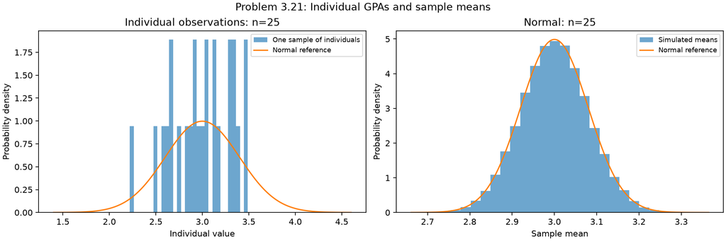

The **sample data distribution** on the left contains 25 individual GPAs. In this sample, the mean was 2.99 and the sample standard deviation was 0.33. These differ somewhat from the population values because of random sampling.

The **sampling distribution** on the right contains 100,000 sample means, with one mean per sample. Its simulated mean was 3.00 and its simulated standard deviation was 0.08. The theoretical values are:

$$ E(\bar Y)=\mu=3.00,\qquad SE(\bar Y)=\frac{\sigma}{\sqrt n}=\frac{0.40}{\sqrt{25}}=0.08 $$

Under the stated normal population model:

$$ Y\sim N(3.00,0.40^2),\qquad \bar Y\sim N(3.00,0.08^2) $$

The important difference is what each observation represents: one student on the left and one group average on the right. The sample means are much less spread out than the individual GPAs. Their distribution is normal under this model because the population is normal, even with $n=25$. The panels have separate axis scales, so the standard deviations give the clearest numerical comparison of their spread.

## Problem 3.26.

When sample data were used to rank states by brain cancer rates, Ellenberg (2014) noted that the highest ranking state (South Dakota) and the nearly lowest ranking state (North Dakota) had relatively small sample sizes. Also, when schools in North Carolina were ranked by their average improvement in test scores, the best and the worst schools were very small schools. Explain how these results could merely reflect how the variability of sample means and proportions depends on the sample size.

Small samples have more sampling variability than large samples. For independent observations, the standard errors of a sample mean and a sample proportion are:

$$ SE(\bar Y)=\frac{\sigma}{\sqrt n},\qquad SE(\hat p)=\sqrt{\frac{p(1-p)}{n}} $$

Both get larger when $n$ gets smaller. For example, a sample one-fourth as large has twice the standard error, when the population variability is the same.

This means a few additional cases can change a cancer rate a lot in a small population, and a few students can change the average improvement a lot in a small school. Even if the underlying rates or average improvements were the same, smaller groups would be more likely to end up near either extreme of a ranking. Their position could therefore reflect sampling variability rather than a real difference in performance or risk. This does not prove that all the groups are the same, but the sample sizes and uncertainty should be considered before interpreting the rankings.

## AI Problem: Simulating Sampling Variability in AI Metrics

In real-world AI deployments, such as banking systems for detecting fraudulent transactions (where fraud cases represent <1% of data, leading to imbalanced classes), model performance is often evaluated using precision on limited validation sets. A baseline model like logistic regression might show 0.90 precision on a small validation sample of n=100, outranking a more sophisticated ensemble method at 0.60, yet on full production data, the ensemble excels.

Use Python to simulate the phenomenon. Assume "true" population precisions for the logistic model (mean ≈0.85, σ=0.10) and ensemble (mean ≈0.88, σ=0.08) follow a lognormal distribution to reflect the positive-skewed nature of precision scores in imbalanced settings. Generate populations of size 10,000 for each model, then perform 1,000 bootstrap resamples at n=50 (small validation) and n=500 (realistic production scale). Compute and plot the sampling distributions of the bootstrap means for both models in each scenario. Calculate the empirical SE for the small-n case. Explain how CLT predicts the distribution shapes, why extreme rankings emerge at low n, and how this variability impacts AI decisions. Propose a mitigation for imbalanced data to prevent errant decisions.

I used the Python app to generate 10,000 scores for each model, using the lognormal distribution requested in the question. For the logistic model, I used a mean of 0.85 and a standard deviation of 0.10. For the ensemble model, I used a mean of 0.88 and a standard deviation of 0.08. I used random seed 42 so the results can be repeated.

For each model, I took 1,000 random samples of 50 scores and then 1,000 samples of 500 scores. These are called **bootstrap samples** because the scores are selected from the generated population with replacement. This means the same score can be selected more than once in a sample. I calculated the average of each sample and plotted those averages below. Model A is the logistic model, and Model B is the ensemble.

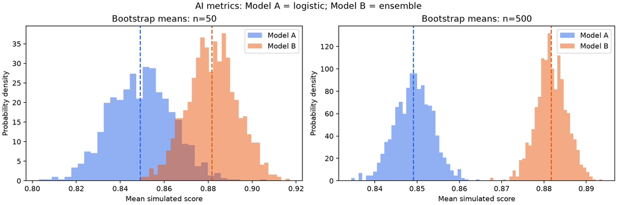

To find the standard error from the simulation, I calculated the standard deviation of the 1,000 sample averages. This tells me how much the averages changed from one sample to another.

| Model | Sample size | Average of the sample averages | Standard error from the simulation (percentage points) |
| --- | --- | --- | --- |
| Logistic | 50 | 0.85 | 1.43 |
| Ensemble | 50 | 0.88 | 1.13 |
| Logistic | 500 | 0.85 | 0.44 |
| Ensemble | 500 | 0.88 | 0.36 |

For the small samples, the standard errors were about 1.43 percentage points for the logistic model and 1.13 percentage points for the ensemble model. I compared these with the formula:

$$ SE(\bar Y)=\frac{\sigma}{\sqrt n} $$

Here, $\sigma$ is the population standard deviation and $n$ is the sample size. For the logistic model:

$$ SE(\bar Y)=\frac{0.10}{\sqrt{50}}\approx0.014142 \approx1.41\text{ percentage points} $$

For the ensemble model:

$$ SE(\bar Y)=\frac{0.08}{\sqrt{50}}\approx0.011314 \approx1.13\text{ percentage points} $$

The simulation results are close to the values from the formula. The sample averages form roughly bell-shaped distributions. This agrees with the Central Limit Theorem: even when the original scores are skewed to the right, the averages become more normally distributed as the sample size increases. With 500 scores per sample, the averages are more tightly grouped and the standard errors are smaller.

With samples of 50, the logistic model had a higher average than the ensemble in 3.50% of the 1,000 comparisons. With samples of 500, this did not happen in any of the 1,000 comparisons. That does not mean it could never happen, but it shows that larger samples gave more consistent results. A small sample can make a model look better just by chance, which could lead someone to choose the wrong model. The large difference of 0.90 versus 0.60 described in the question was not typical of this simulation.

One issue with the question's model is that real precision cannot be higher than 1, or 100%, but a lognormal distribution can produce values above 1. This happened for 7.53% of the logistic scores and 7.85% of the ensemble scores. I left them as generated to follow the question. The simulation helps show how sample averages vary, but these scores are not all possible real precision values.

For fraud detection, I would test both models on the same larger set of transactions, with enough fraud cases to make the comparison useful. I would repeat the comparison using different samples instead of deciding from one small sample. The test data should also have a similar share of fraud cases to what the models would see in actual use. Precision measures how many transactions flagged as fraud really are fraud, so having very few flagged transactions makes it hard to judge a model. If I added extra fraud examples to help train the models, I would keep those added examples out of the test data.